# 3_Analysis

# Characteristics of included studies

```
## [1] "--------------------------------------------------"
## [1] "year"
## [1] ""
## [1] "Mean: 2012.62"
## [1] "Median: 2015"
## [1] ""
## [1] ""
## [1] ""
## [1] "--------------------------------------------------"
## [1] "pubStatus"
## [1] ""
## # A tibble: 2 x 2
##   pubStatus             n
##   <chr>             <int>
## 1 Not peer-reviewed     1
```

[output cut: 333 more lines]

# Meta-analysis

Mixed-effects model with robust variance estimation using `metafor`

## Post-test effects

### Intercept-only model

#### Using post-test data only

```
##
## Number of outcomes:   21
## Number of clusters:   13
## Outcomes per cluster: 1-4 (mean: 1.62, median: 1)
##
## Model Results:
##
## estimate      se     tval    pval    ci.lb    ci.ub
##  -0.2082  0.0567  -3.6696  0.0032  -0.3318  -0.0846  **
##
## ---
## Signif. codes:  0 '***' 0.001 '**' 0.01 '*' 0.05 '.' 0.1 ' ' 1
```

#### Using pre- and post-test data

```
##
## Number of outcomes:   21
## Number of clusters:   13
## Outcomes per cluster: 1-4 (mean: 1.62, median: 1)
##
## Model Results:
##
## estimate      se     tval    pval    ci.lb    ci.ub
##  -0.1863  0.0404  -4.6102  0.0006  -0.2743  -0.0982  ***
##
## ---
## Signif. codes:  0 '***' 0.001 '**' 0.01 '*' 0.05 '.' 0.1 ' ' 1
```

### Forest plot:

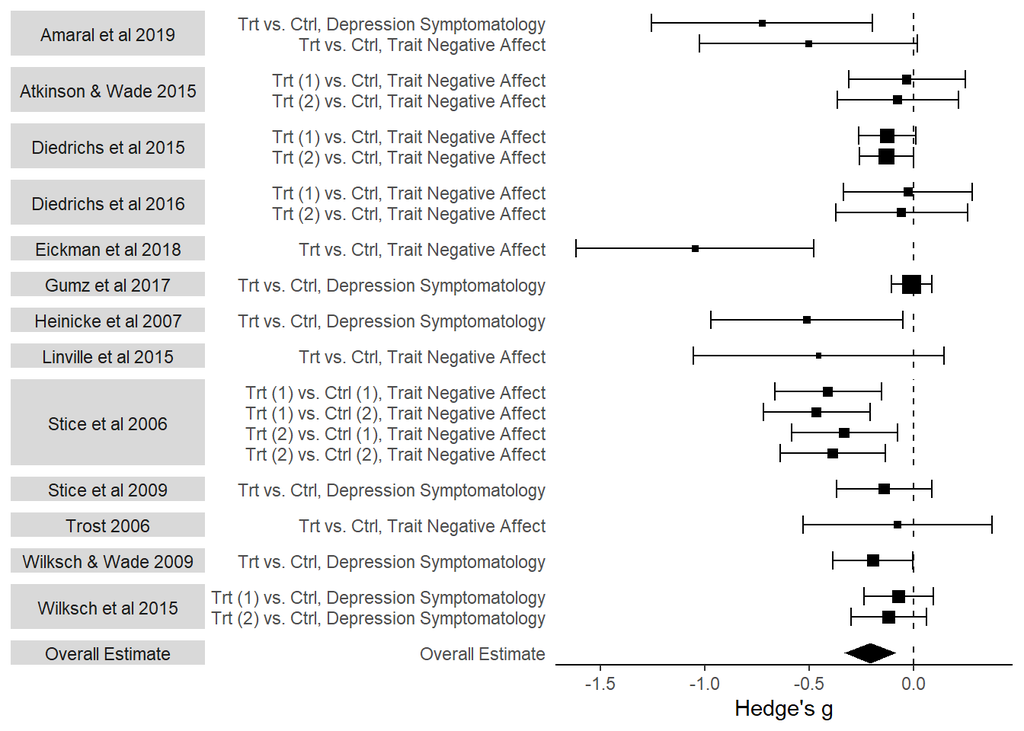

### Risk of bias assessment

We will assess publication bias with a funnel plot and Egger’s test. Since we cannot use `regtest` with `rma.mv`, we will instead conduct it manually within the framework of our multilevel model. We do this by regressing each effect’s normalized effect estimate (estimate divided by its standard error) against precision (reciprocal of the standard error of the estimate) and testing the significance of the intercept.

```
##
## Number of outcomes:   21
## Number of clusters:   13
## Outcomes per cluster: 1-4 (mean: 1.62, median: 1)
##
## Test of Moderators (coefficient 2):
## F(df1 = 1, df2 = 11) = 0.8065, p-val = 0.3884
##
## Model Results:
##
##                    estimate      se     tval    pval    ci.lb    ci.ub
## intrcpt             -2.2310  0.8310  -2.6849  0.0212  -4.0600  -0.4021  *
## precision.post_t2    0.0868  0.0966   0.8981  0.3884  -0.1259   0.2994
##
## ---
## Signif. codes:  0 '***' 0.001 '**' 0.01 '*' 0.05 '.' 0.1 ' ' 1
```

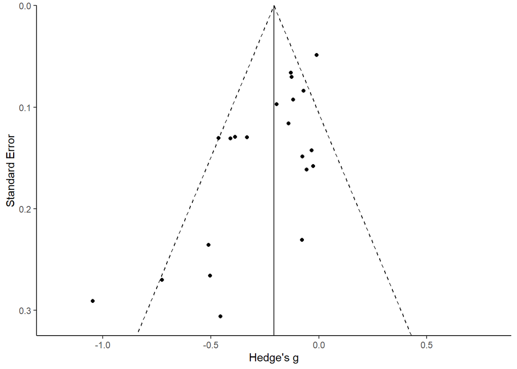

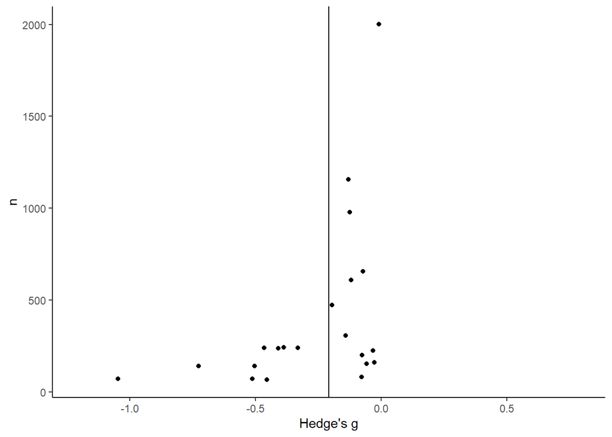

### Moderation tests

Moderation tests for each of the following variables (pre-registered), including subgroups with n >= 3 studies (not effect sizes).

See for minimum n/group in moderator test (they suggest 4, we use 3): Fu, R., Gartlehner, G., Grant, M., Shamliyan, T., Sedrakyan, A., Wilt, T. J., … & Trikalinos, T. A. (2011). Conducting quantitative synthesis when comparing medical interventions: AHRQ and the Effective Health Care Program. Journal of clinical epidemiology, 64(11), 1187-1197. https://www.researchgate.net/post/Does-anyone-have-any-citations-supporting-a-specific-number-of-studies-eg-3-or-more-per-subgroup-in-a-categorical-moderator-analysis

To decompose effects of effect-level and study-level moderation, see page 13: https://cran.r-project.org/web/packages/robumeta/vignettes/robumetaVignette.pdf

To use random slopes for moderators: `random = ~ mod | studyID, struct="GEN"` https://stats.stackexchange.com/questions/526230/in-a-multi-level-meta-analysis-are-moderator-variables-random-or-fixed-effects?noredirect=1#comment969486_526230

Pre-registered moderators: `year`, `pubStatus`, `country`, `sampleSource`, `meanAge`, `pctFemale`, `pctNonwhite`, `interventionType`, `riskScreen`, `outcome`, `controlCond`, `deliveryFormat`, `target`, `provider`, `supervision`, `length.minutes`, `length.sessions`, `length.days`, `trtCompletion`, `studyCompletion.post`

Added after pre-registration: `interventionParticipant`, `meanType`, `randUnits`

Moderators tested for quality assessment: `blindAssign`, `manual`, `preTraining`, `supervision`, `studyCompletion.post`

Dropped due to zero variation:

- `pctSexualMinority`: All `NA`
- `respondent`: All “Youth-reported”
- `manual`: All “Treatment manual used” or `NA`
- `preTraining`: All “Present” or `NA`

Dropped because only one category had >= 3 studies:

- `pubStatus`: Only 1 not “Peer-reviewed”
- `sampleSource`: Only 1 not “Community sample”
- `delieryFormat`: Only 2 not “Group”
- `target`: Only 2 not “Body dissatisfaction”
- `interventionParticipant`: Only 2 not “Youth”
- `meanType`: Only 1 not “Unadjusted”
- `blindAssign`: Only 1 not “No blind assignment”

Collapsed categories to allow for analysis: *(Neither of these ping as significant; maybe don’t collapse categories)*

- `controlCond`: “Psychoeducation” (2) and “Other” (1) combined into “Active control”
- `provider`: “Self-administered” (1) and “Lay-administered” (2) combined into “Non-clinician-administered”

| moderator | level | nStudies | nES | Subgroup Analysis subgroupEst | Subgroup Analysis subgroupP | Subgroup Analysis coef | Moderator Test overallStat | Moderator Test overallP |
| --- | --- | --- | --- | --- | --- | --- | --- | --- |
| Year |  | 13 | 21 |  |  | 0.005 | t(11) = 0.302 | 0.768 |
| Country |  |  |  |  |  |  | F(1, 11) = 4.379 | 0.060 |
|  | Other (Non-North America) | 8 | 13 | -0.112 | 0.017 |  |  |  |
|  | USA | 5 | 8 | -0.368 | 0.051 |  |  |  |
| Intervention Type |  |  |  |  |  |  | F(1, 10) = 1.34 | 0.274 |
|  | Indicated prevention | 7 | 12 | -0.290 | 0.015 |  |  |  |
|  | Universal prevention | 5 | 7 | -0.119 | 0.064 |  |  |  |
| Risk Screening |  |  |  |  |  |  | F(1, 10) = 1.73 | 0.218 |
|  | No risk screening | 6 | 9 | -0.102 | 0.036 |  |  |  |
|  | Screen on BD | 6 | 11 | -0.268 | 0.033 |  |  |  |
| Mean Age |  | 12 | 20 |  |  | -0.054 | t(10) = -2.3 | 0.044 |
| Percent Female |  | 13 | 21 |  |  | -0.003 | t(11) = -1.669 | 0.123 |
| Percent Non-white |  | 11 | 18 |  |  | -0.008 | t(9) = -3.742 | 0.005 |
| Provider |  |  |  |  |  |  | F(1, 11) = 0.004 | 0.949 |
|  | Clinician-administered | 10 | 16 | -0.199 | 0.009 |  |  |  |
|  | Non-clinician-administered | 4 | 5 | -0.263 | 0.235 |  |  |  |
| Length (Minutes) |  | 11 | 18 |  |  | 0.000 | t(9) = -0.716 | 0.492 |
| Length (Sessions) |  | 12 | 20 |  |  | -0.010 | t(10) = -0.657 | 0.526 |
| Length (Days) |  | 12 | 20 |  |  | -0.007 | t(10) = -2.232 | 0.050 |
| Treatment Completion Rate |  | 8 | 14 |  |  | 0.008 | t(6) = 2.145 | 0.076 |
| Control Condition |  |  |  |  |  |  | F(1, 11) = 0 | 1.000 |
|  | Active control | 3 | 4 | -0.286 | 0.087 |  |  |  |
|  | Waitlist/no treatment | 11 | 17 | -0.217 | 0.009 |  |  |  |
| Outcome |  |  |  |  |  |  | F(1, 11) = 0.286 | 0.603 |
|  | Depression Symptomatology | 6 | 7 | -0.151 | 0.057 |  |  |  |
|  | Trait Negative Affect | 8 | 14 | -0.259 | 0.025 |  |  |  |
| Facilitator Supervision |  |  |  |  |  |  | F(1, 10) = 0.069 | 0.799 |
|  | No supervision | 6 | 9 | -0.199 | 0.048 |  |  |  |
|  | Supervision | 6 | 10 | -0.274 | 0.061 |  |  |  |
| Post-test Data Availability |  | 13 | 21 |  |  | 0.007 | t(11) = 1.926 | 0.080 |
| Randomized Units |  |  |  |  |  |  | F(1, 10) = 9.634 | 0.011 |
|  | < 30 per group | 7 | 11 | -0.094 | 0.024 |  |  |  |
|  | >= 30 per group | 5 | 9 | -0.340 | 0.017 |  |  |  |

*End of post-test effects analysis.*

## Follow-up effects

### Intercept-only model

#### Using follow-up data only

```
##
## Number of outcomes:   29
## Number of clusters:   10
## Outcomes per cluster: 1-8 (mean: 2.90, median: 2)
##
## Model Results:
##
## estimate      se     tval    pval    ci.lb    ci.ub
##  -0.0643  0.0274  -2.3429  0.0438  -0.1263  -0.0022  *
##
## ---
## Signif. codes:  0 '***' 0.001 '**' 0.01 '*' 0.05 '.' 0.1 ' ' 1
```

#### Using pre-test and follow-up data

```
##
## Number of outcomes:   29
## Number of clusters:   10
## Outcomes per cluster: 1-8 (mean: 2.90, median: 2)
##
## Model Results:
##
## estimate      se     tval    pval    ci.lb    ci.ub
##  -0.0713  0.0217  -3.2798  0.0095  -0.1204  -0.0221  **
##
## ---
## Signif. codes:  0 '***' 0.001 '**' 0.01 '*' 0.05 '.' 0.1 ' ' 1
```

### Forest plot

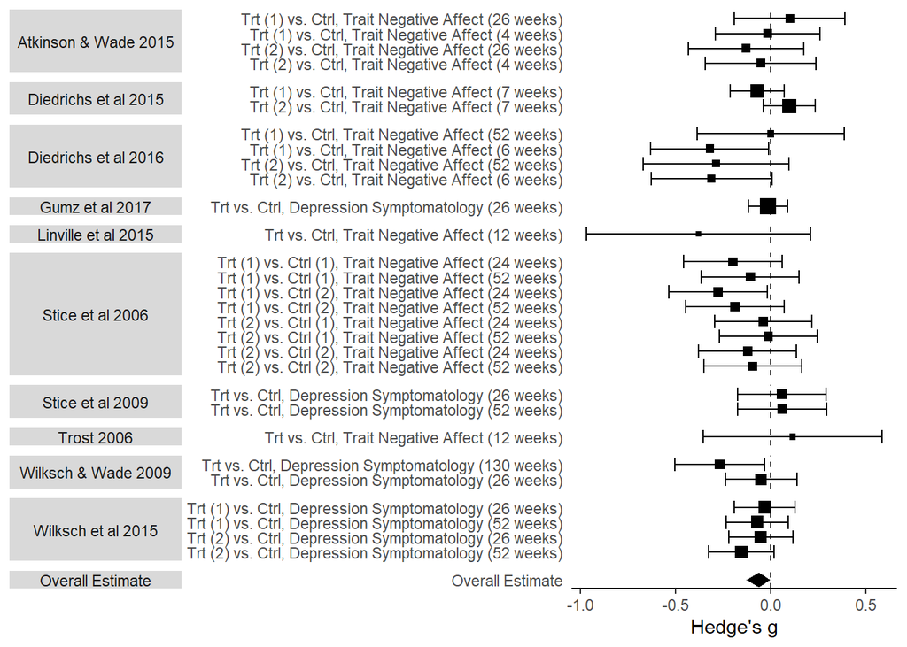

### Risk of bias assessment

We will assess publication bias with a funnel plot and Egger’s test. Since we cannot use `regtest` with `rma.mv`, we will instead conduct it manually within the framework of our multilevel model. We do this by regressing each effect’s normalized effect estimate (estimate divided by its standard error) against precision (reciprocal of the standard error of the estimate) and testing the significance of the intercept.

```
##
## Number of outcomes:   29
## Number of clusters:   10
## Outcomes per cluster: 1-8 (mean: 2.90, median: 2)
##
## Test of Moderators (coefficient 2):
## F(df1 = 1, df2 = 8) = 5.2013, p-val = 0.0520
##
## Model Results:
##
##                  estimate      se     tval    pval     ci.lb   ci.ub
## intrcpt           -8.3937  4.0984  -2.0481  0.0747  -17.8447  1.0572  .
## precision.fu_t2    0.8714  0.3821   2.2806  0.0520   -0.0097  1.7524  .
##
## ---
## Signif. codes:  0 '***' 0.001 '**' 0.01 '*' 0.05 '.' 0.1 ' ' 1
```

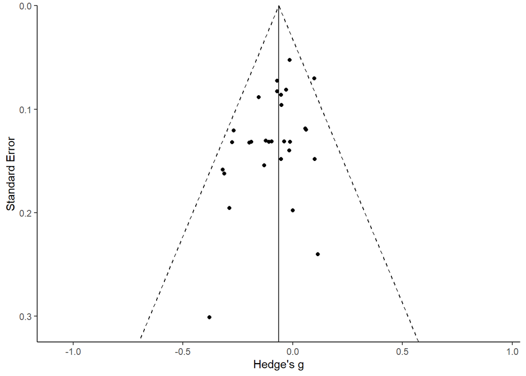

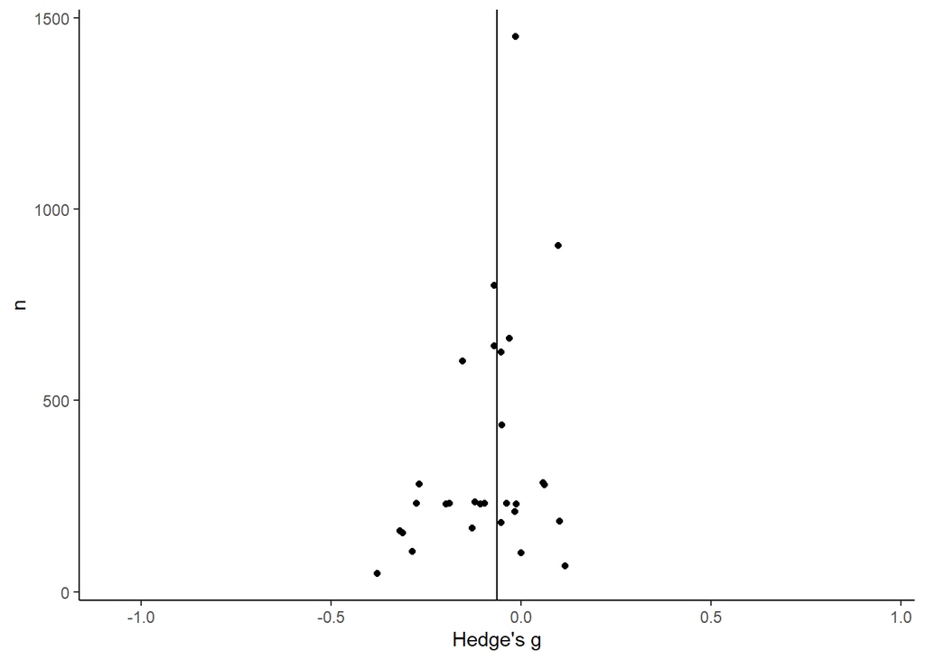

### Moderation tests

Moderation tests for each of the following variables (pre-registered) with n >= 3 studies (not effect sizes) per group.

Pre-registered moderators: `year`, `pubStatus`, `country`, `sampleSource`, `meanAge`, `pctFemale`, `pctNonwhite`, `interventionType`, `riskScreen`, `outcome`, `controlCond`, `deliveryFormat`, `target`, `provider`, `supervision`, `length.minutes`, `length.sessions`, `length.days`, `trtCompletion`, `studyCompletion`, `followUpLength`

Added after pre-registration: `interventionParticipant`, `meanType`, `randUnits`

Moderators tested for quality assessment: `blindAssign`, `manual`, `preTraining`, `supervision`, `studyCompletion`

Dropped due to zero variation:

- `pctSexualMinority`: All `NA`
- `respondent`: All “Youth-reported”
- `manual`: All “Treatment manual used” or `NA`
- `preTraining`: All “Present” or `NA`

Dropped because only one category had >= 3 studies:

- `pubStatus`: Only 1 not “Peer-reviewed”
- `sampleSource`: Only 1 not “Community sample”
- `delieryFormat`: Only 1 not “Group”
- `target`: Only 2 not “Body dissatisfaction”
- `provider`: Only 2 not “Clinician-administered”
- `interventionParticipant`: Only 2 not “Youth”
- `meanType`: Only 1 not “Unadjusted”
- `blindAssign`: Only 1 not “No blind assignment”

Collapsed categories to allow for analysis: *(Not significant; maybe don’t collapse categories)*

- `controlCond`: “Psychoeducation” (2) and “Other” (1) combined into “Active control”

| moderator | level | nStudies | nES | Subgroup Analysis subgroupEst | Subgroup Analysis subgroupP | Subgroup Analysis coef | Moderator Test overallStat | Moderator Test overallP |
| --- | --- | --- | --- | --- | --- | --- | --- | --- |
| Year |  | 10 | 29 |  |  | 0.003 | t(8) = 0.512 | 0.622 |
| Country |  |  |  |  |  |  | F(1, 8) = 0 | 0.989 |
|  | Other (Non-North America) | 6 | 17 | -0.062 | 0.103 |  |  |  |
|  | USA | 4 | 12 | -0.056 | 0.474 |  |  |  |
| Intervention Type |  |  |  |  |  |  | F(1, 7) = 0.866 | 0.383 |
|  | Indicated prevention | 5 | 16 | -0.104 | 0.202 |  |  |  |
|  | Universal prevention | 4 | 9 | -0.043 | 0.215 |  |  |  |
| Risk Screening |  |  |  |  |  |  | F(1, 8) = 1.278 | 0.291 |
|  | No risk screening | 5 | 13 | -0.041 | 0.158 |  |  |  |
|  | Screen on BD | 5 | 16 | -0.104 | 0.202 |  |  |  |
| Mean Age |  | 10 | 29 |  |  | -0.004 | t(8) = -0.228 | 0.825 |
| Percent Female |  | 10 | 29 |  |  | -0.001 | t(8) = -0.832 | 0.429 |
| Percent Non-white |  | 9 | 28 |  |  | 0.000 | t(7) = -0.037 | 0.972 |
| Length (Minutes) |  | 9 | 25 |  |  | 0.000 | t(7) = 0.243 | 0.815 |
| Length (Sessions) |  | 10 | 29 |  |  | -0.005 | t(8) = -0.444 | 0.669 |
| Length (Days) |  | 10 | 29 |  |  | 0.000 | t(8) = 0.007 | 0.995 |
| Treatment Completion Rate |  | 5 | 19 |  |  | -0.007 | t(3) = -3.034 | 0.056 |
| Control Condition |  |  |  |  |  |  | F(1, 8) = 1.634 | 0.237 |
|  | Active control | 3 | 7 | -0.043 | 0.568 |  |  |  |
|  | Waitlist/no treatment | 8 | 22 | -0.075 | 0.046 |  |  |  |
| Outcome |  |  |  |  |  |  | F(1, 8) = 0.384 | 0.553 |
|  | Depression Symptomatology | 4 | 9 | -0.051 | 0.154 |  |  |  |
|  | Trait Negative Affect | 6 | 20 | -0.085 | 0.143 |  |  |  |
| Follow-up Length |  |  |  |  |  |  | F(1, 8) = 0.003 | 0.960 |
|  | Between 3 and 12 weeks | 5 | 8 | -0.090 | 0.325 |  |  |  |
|  | Greater than 12 weeks | 7 | 21 | -0.070 | 0.030 |  |  |  |
| Facilitator Supervision |  |  |  |  |  |  | F(1, 7) = 0.571 | 0.475 |
|  | No supervision | 4 | 11 | -0.072 | 0.029 |  |  |  |
|  | Supervision | 5 | 14 | -0.034 | 0.431 |  |  |  |
| studyCompletion |  | 10 | 29 |  |  | 0.000 | t(8) = 0.041 | 0.969 |
| Randomized Units |  |  |  |  |  |  | F(1, 7) = 0.04 | 0.848 |
|  | < 30 per group | 6 | 17 | -0.062 | 0.103 |  |  |  |
|  | >= 30 per group | 3 | 11 | -0.034 | 0.705 |  |  |  |

*End of follow-up effects analysis.*